# Getting Started with `rexamsll`

Brighton Pauli

May 14, 2023

This document should be integrated into `pkgdown` once it is available.

# 1 Install

While `rexamsll` is in development, the most recently pushed version can be installed through GitHub using the devtools library.

```r
install.packages("devtools")
```

In order to gain access to this package’s source code, you’ll need a GitHub account and permission from a project administrator to access the repository. If haven’t worked with git before, check out https://docs.github.com/en/get-started/getting-started-with-git.

Once you have a git account, you need to create an authentication token so R can access your repositories. This just means signing in once to get a special password from GitHub that R can use from then on.

To start, input your GitHub username and the email associated with your account in their respective strings below, and run the code cell.

```r
usethis::use_git_config(user.name = "<USERNAME>",
                        user.email = "<YOUR>@<EMAIL>.com")
usethis::create_github_token()
```

This should open your browser and ask you to sign into GitHub before bringing you to a page titled “New personal access token”.

Start by providing a reason for this token’s creation in the “Note” section. You can also change the expiration date on the token, though the default value of 30 days works perfectly well.

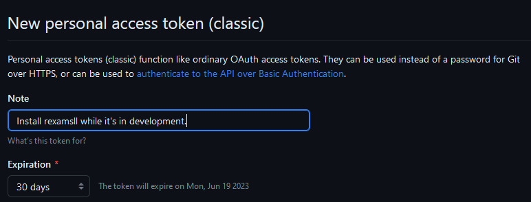

You should not need to change any of the selections in the “Select scopes” section. The “repo” section that is enabled by default should be all that you need to give R access to.

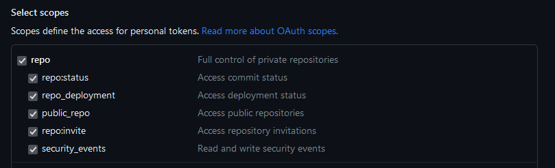

Now, click the green “Create Token” at the bottom of the page. You should be presented with a page that looks like the following, with some code that starts with `ghp_`. (Note that the code has been censored in this example image.)

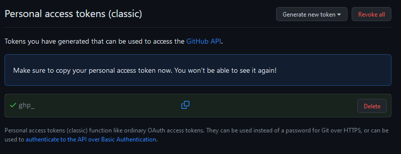

Copy this code and, optionally, save it somewhere secure to use later. Paste it over the text that says `<AUTH CODE HERE>` in the chunk below. Be sure to delete the `<` and `>`; only your authentication code should be within the quotes. Then run the code chunk to install rexamsll.

```r
library(devtools)
install_github("examLing/rexamsll", ref = "main",
               auth_token = "<AUTH CODE HERE>")
```

To check that rexamsll was installed properly, run the following code chunk and make sure there are no errors.

```r
library(rexamsll)
```

# 2 Generate `.Rmd` Files from Google Sheets

## 2.1 Build the Sheet

Create a new Google Sheets document, and fill row 1 with the following headers:

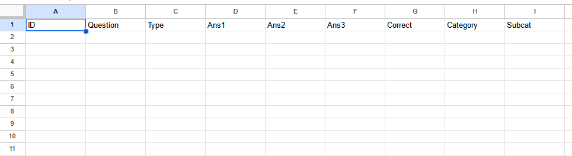

* You may use any number of `Ans` columns. Simply label them accordingly.

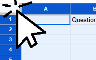

Then, set the entire Sheet to plain text. To do this, Press the button that says “123” (to the left of the font-selection box) and choose “Plain Text”.

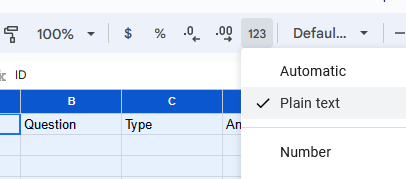

Doing this ensures that any numbers you input will be saved exactly as you write them.

Then, write the main body text of the question in the `Question` column. `rexamsll` uses [R-markdown](https://r02pro.github.io/rmd-text-formating.html) to format text, so you can, for example, **bold** text by typing “**” on each side.

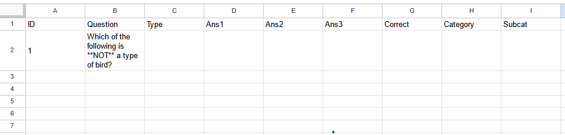

The `Type` column dictates what kind of answer is expected for this question. There are three main choices:

1. **schoice** - There is a single correct answer, and all other options are wrong.
2. **mchoice** - There is any number of correct answers, and the student is graded on how many of these select without choosing incorrect answers.
3. **string** - There are no provided answers and the student is instead given an area to input text. The student’s response must *exactly* match the correct answer to receive credit.

If the `Type` is **NOT** “string”, provide all of the answers that the student will need to choose from in the columns starting with `Ans`, including both correct and incorrect options. You *do not* need to use all `Ans` columns.

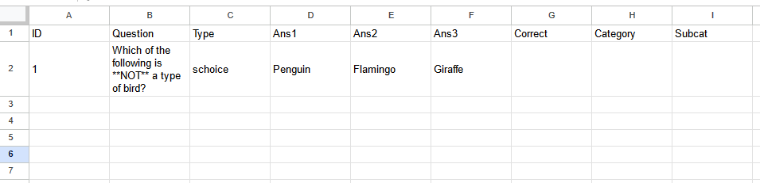

The `Correct` column is used differently depending on the `Type`.

For **schoice** questions, the `Correct` value should be the *index* corresponding to the correct answer. In the example provided, the correct answer is “Giraffe”, which is under the column `Ans3`. Therefore, the `Correct` column should say “3”.

For **mchoice** questions, the `Correct` value should be a comma-separated list of all correct indices. For example, if the correct answers lie in the columns `Ans1` and `Ans3`, this cell should say “1, 3”.

For **string** questions, the `Correct` value should be the exact correct answer. For example, if the question is “What color is chlorophyll?”, this cell should say “green”.

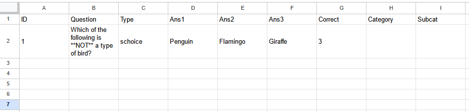

The `Category` and `SubCat` columns are used for organization and naming files. Their values should be short, informative names that will help you keep track of topics. Questions with the same `Category` values should appear on the same tests.

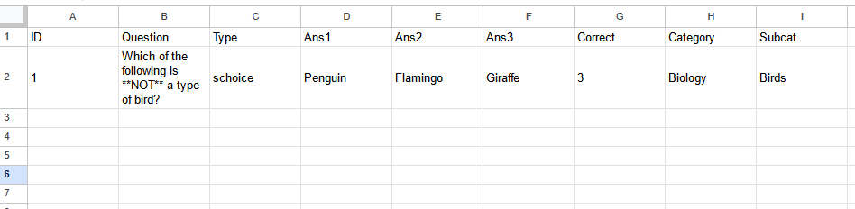

Now, add another row for every question you want to generate a `.Rmd` file for.

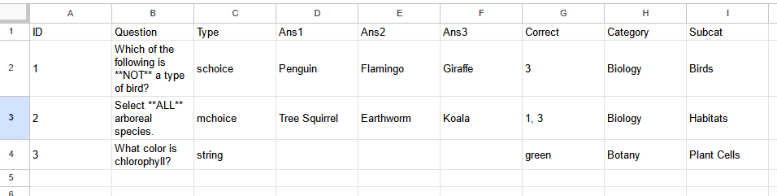

Give your Sheet a title and, optionally, click “View” -> “Freeze” -> “1 row” to keep the header row visible while scrolling.

[figure not shown]

## 2.2 Import into R

```r
library(rexamsll)
```

```r
google2rmd(
   "https://docs.google.com/spreadsheets/d/1NCWf1bGPA5TzUtXjM4PmfT-lhJC2FF5cRHxtD5Rczk0/edit#gid=0",
   "Example"
)
```

# 3 Design Dynamic Questions